# Injury Pain Visualization and Prediction

Cooper Schumacher

November, 2017

| **Primary skills** | **Primary Programs** |
| --- | --- |
| Data visualization | [Tableau](https://public.tableau.com/views/InjuryPrediction/Dashboard1?:embed=y&:display_count=yes) |
| Time series modeling | R |

# Motivation

I have been an athlete my whole life, including playing collegiate soccer at Whitman College. I have unfortunately suffered from recurring hip injuries. In the summer of 2017 I played on Seattle’s top men’s club ultimate frisbee team. During that time my injury acted up and I decided to collect data on myself.

[figure not shown]

Playing soccer for Whitman College

# Objectives

1. **Visualize and better understand how my activities influence pain levels**
2. **Create a prediction tool for pain levels**
- *To help me plan my training and participation in team events*

# Data

I created a Google survey (filled out daily) documenting my daily pain levels, as well as other factors that may influence my injuries (e.g. participation in high intensity sports, lifting weights, physical therapy exercises, hours sitting, hours spent looking at screens, sleep the previous night, stress levels etc.).

# Modeling

### Important features of the data considered

- They are time series data from a single individual (me), with suspected autocorrelation structure
- The sample size is small

### Model choices

Given the above features, I considered time series models, and looked at ACF and PACF plots to help choose autocorrelation and moving average parts. I used regression models with ARMA errors, in order to account for autocorrelation, moving average, as well as adjust for covariates. Because of the large risk of overfitting the data with such a small sample size, I only considered a few different sets of adjustment covariates. The final model (chosen based on the validation criteria described below) only adjusted for participation in high intensity sports.

### Validation

Since observations are from a time series I could not use typical methods of validation such as k-fold cross-validation. Instead, I used a “rolling origin” approach, which forecasts the $m$th observation with the previous $m-1$ observations, and repeats that for all observations. Since models cannot be fit with only a few observations, a minimum value of $m$ was chosen and only the observations from then on were actually predicted. The mean squared error of these single predictions was then used for model validation.

# Adressing my Goals

1. **Visualize and better understand how my activities influence pain levels**

Visual findings are presented in this interactive **[Tableau Dashboard](https://public.tableau.com/views/InjuryPrediction/Dashboard1?:embed=y&:display_count=yes)**.

2. **Create a prediction tool for pain levels**

In the dashboard I also implemented forecasting of the next day’s pain (based on the model descrived above) with input for whether I play sports the next day. During the season, I used these forecasts (in addition to other considerations) to help plan my training and participation in sports for the following days.

- *Note: I actually used a slightly different Tableau dashboard created on Tableau desktop, which allows for R scripts integrated into calculated fields. Therefore each night I could just refresh the connection to the data source and automatically have the new forecast. However, R integration is not available on Tableau Public and so I had to run forecasts in my local R server and export data to Tableau Public in order to create this publically available dashboard.*

[interactive chart not shown]

### Daily Pain Levels and Forecasting (Top Plot)

- **Pain levels typically increase from playing sports (no surprise!)**: seen by how the spikes in pain levels usually occur with participation in sports. *(Note: the spikes without playing sports on Sept. 6th and 20th both occured because of receiving a dry needling treatment)*

### Lag Plot (Bottom Plot)

- **Interpreting the plot:** The lag plot on the bottom left of the dashboard shows the relationship between pain levels one day (y-axis) compared to the previous day (x-axis), with coloring based on sports participation in those two days. With this plot, if a point is below the diagonal line, that means that pain was worse the previous day and improves the second day. A point above the diagonal means pain increases the second day.
- **Participation in sports typically makes pain worse and rest typically reduces pain (same conclusion as first plot)**. This is seen by how the when sports are played the second day (orange or red), the points are almost always above the diagonal line, and when sports are not played (green and blue) the points are typically below the diagnoal line.
- **However, pain from playing sports may linger for one or more days**. This is seen by how the green points (playing sports the first day but not the second), are more frequently above/closer to the diagonal line than the blue points (playing sports neither day).

# Key Takeaways

So how did I actually use this information?

The main insight it provided was that I should think about my activities multiple days ahead of time and try and avoid high intensity sports multiple days in a row if I can. This was far from ground breaking insight, but that was expected given that I have suffered from similar issues for years and already have extensive knowledge of the issue. More than anything having actual data gave me support for what I know, and kept me from ignoring those facts. On a day where I really wanted to play, but knew I probably shouldn’t for my health, I now had an additional voice telling me to be cautious.

# Annotated R Code for Time Series Modeling

### Data Management

Because I created my own Google survey, the resulting data required almost no cleaning.

```r
# packages for importing data, time series and table formatting
library(readr)
library(forecast)
library(xtable)

# load dataset
setwd("C:/Users/Cooper/OneDrive/Documents/Data Science Injury Prediction Project")
injury <- read_csv("InjurySurveyResponses_until_10_23_17.csv")

# sample size
n <- dim(injury)[1]

# create time series object for pain levels
ts <- ts(injury$AveragePainLevels)
```

### Descriptives

The plot below gives the same line plot I created in Tableau.

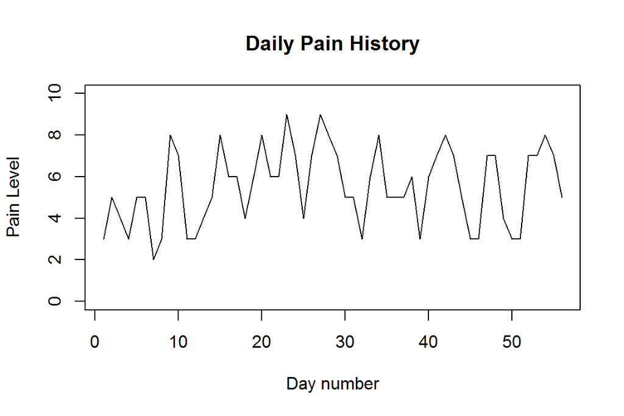

```r
# Pain History Plot
plot(ts, ylab = "Pain Level", ylim = c(0, 10), xlab = "Day number", main = "Daily Pain History")
```

We now consider descriptive plots used to determine the time series model specification. A plot of the Sample Autocorrelation Function (ACF) and Partial Autocorrelation Function (PACF) are provided.

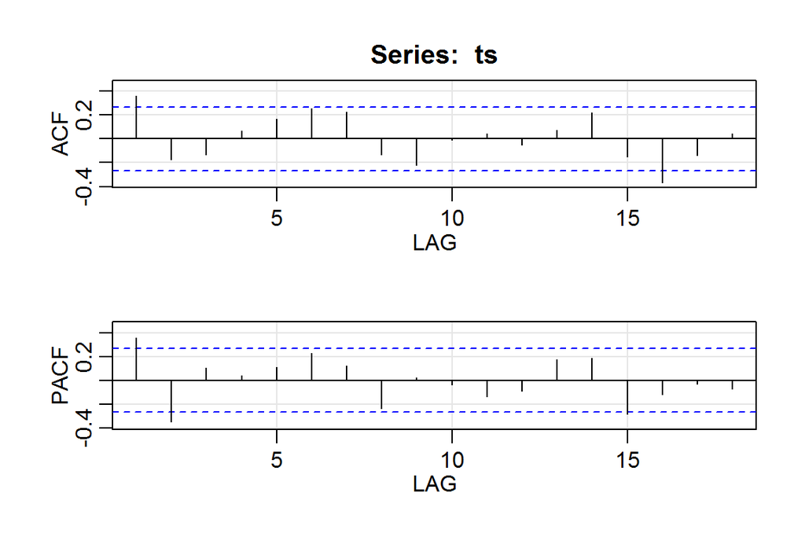

```r
# ACF and PACF plots
library(astsa)
acf2(ts)
```

The spike at the 1st lag in the ACF plot suggests the moving average component of our time series model should be 1. The spikes at the 1st and 2nd lags in the PACF plot suggest that the autoregressive component should be 2.

### Adjustment Covariates

We consider three sets of adjustment covariates. The sets were chosen based on my knowledge of what have seemed most influential to my pain levels in the past. With such a small sample size I wanted to be cautious of overfitting the data (even with cross-validation being used) and so limited the number of adjustment covariates sets I tried.

```r
# Minimal adjustment (just whether played high intensity sports)
x1 <- as.data.frame(cbind(sports = injury$HighIntensitySports))

# Moderate adjustment (add tissue work, lower body lifting)
x2 <- as.data.frame(cbind(injury$HighIntensitySports, injury$TissueWork, injury$LowerBodyLifting))

# Most adjustment (add Stretching, PT exercises)
x3 <- as.data.frame(cbind(injury$HighIntensitySports, injury$TissueWork, injury$LowerBodyLifting,
    injury$Stretching, injury$PTexercises))
```

### Model Validation

I used a cross-validation method appropriate for time series: “forecast evaluation with a rolling origin”. Essentially I chose a minimum number of observations to fit the model, $k$, then use those $k$ observations to predict the $(k+1)$th observation, then use the first $(k+1)$ observations to predict the $(k+2)$th observation and so on. After all points have been predicted (besides the first $k$ observations of course), we compare the predictions to the actual pain levels and calculate the MSE of these predictions.

```r
# Framework for 'rolling origin' cross-validation
h <- 1  #number of points to predict
k <- 10  #minimum number of points used to fit model

# matrix to fill in CV results
cv.mat <- matrix(rep(NA, 4 * (n - k)), ncol = 4)

# model unadjusted for covariates
for (i in k:(n - 1)) {
    # define vector for first i days
    y.short <- ts[1:i]
    # fit model based on first i days
    fit.short <- arima(as.matrix(y.short), order = c(2, 0, 1), method = "ML")
    # predict (i+1)th day
    next.forecast <- forecast(object = fit.short, h = h)
    # record error between observed and predicted pain on (i+1)th day
    cv.mat[i - k + 1, 1] <- (next.forecast$mean - ts[i + 1])
}


# minimal adjustment
for (i in k:(n - 1)) {
    # define vectors for first i days
    y.short <- ts[1:i]
    X.short <- x1[1:i, ]
    # fit model based on first i days
    fit.short <- arima(as.matrix(y.short), order = c(2, 0, 1), xreg = cbind(X.short),
        method = "ML")
    # predict (i+1)th day
    next.forecast <- forecast(object = fit.short, h = h, xreg = x1[i + 1, ])
    # record error between observed and predicted pain on (i+1)th day
    cv.mat[i - k + 1, 2] <- (next.forecast$mean - ts[i + 1])
}

# medium adjustment
for (i in k:(n - 1)) {
    # define vectors for first i days
    y.short <- ts[1:i]
    X.short <- x2[1:i, ]
    # fit model based on first i days
    fit.short <- arima(as.matrix(y.short), order = c(2, 0, 1), xreg = cbind(X.short),
        method = "ML")
    next.forecast <- forecast(object = fit.short, h = h, xreg = x2[i + 1, ])
    # record error between observed and predicted pain on (i+1)th day
    cv.mat[i - k + 1, 3] <- (next.forecast$mean - ts[i + 1])
}

# most adjustment
for (i in k:(n - 1)) {
    # define vectors for first i days
    y.short <- ts[1:i]
    X.short <- x3[1:i, ]
    # fit model based on first i days
    fit.short <- arima(as.matrix(y.short), order = c(2, 0, 1), xreg = cbind(X.short),
        method = "ML")
    # predict (i+1)th day
    next.forecast <- forecast(object = fit.short, h = h, xreg = x3[i + 1, ])
    # record error between observed and predicted pain on (i+1)th day
    cv.mat[i - k + 1, 4] <- (next.forecast$mean - ts[i + 1])
}

# Cross validation MSE
cv.mse <- apply(cv.mat^2, 2, mean)

# Print table
tab <- rbind(round(cv.mse, digits = 2))
colnames(tab) <- c("unadjusted", "minimal adjustment", "medium adjustment",
    "most adjustment")
row.names(tab) <- c("CV MSE")
xtab <- xtable(tab)
print(xtab, type = "html")
```

|  | unadjusted | minimal adjustment | medium adjustment | most adjustment |
| --- | --- | --- | --- | --- |
| CV MSE | 3.33 | 2.76 | 3.54 | 6.43 |

The model only adjusted for high intensity sports performs best. With such a small sample size, it is reasonable that we cannot adjust for many variables without overfitting the data. We can look closer at the output for this model:

```r
# final model
final.fit <- arima(as.matrix(ts), order = c(2, 0, 1), xreg = x1)
final.fit
```

```
##
## Call:
## arima(x = as.matrix(ts), order = c(2, 0, 1), xreg = x1)
##
## Coefficients:
##          ar1      ar2     ma1  intercept  sports
##       0.2842  -0.3117  0.3687     5.1168  1.1490
## s.e.  0.2360   0.1673  0.2355     0.2667  0.2809
##
## sigma^2 estimated as 1.967:  log likelihood = -98.73,  aic = 209.47
```

With this model the estimated effect of playing sports is a 1.15 higher pain level on average.

### Forecasting

*“Prediction? … Pain.”* -Clubber Lang

Finally I forecast pain levels for the next day. I integrated similar scripts in Tableau to automatically forecast the next day’s pain with the input of either playing sports or not. Multiple days could also be predicted, but I would recomment only one or two days as the model does not posess the complexity or training data to predict very far out.

```r
# if play sports the next day
newx1 <- c(1)
forecast(object = final.fit, h = 1, xreg = newx1)
```

```
##    Point Forecast    Lo 80    Hi 80    Lo 95    Hi 95
## 57       5.717597 3.920367 7.514827 2.968971 8.466223
```

```r
# if don't play sports the next day
newx2 <- c(0)
forecast(object = final.fit, h = 1, xreg = newx2)
```

```
##    Point Forecast    Lo 80    Hi 80    Lo 95    Hi 95
## 57       4.568568 2.771338 6.365798 1.819942 7.317194
```

We see that the predicted pain levels are higher if I play sports. The uncertainty of the model is highlighted by the very wide confidence intervals. We can also make a forecast plot similar to as is done in the Tableau Dashboard. Here we show the forecast and confidence intervals for if I played sports the next day.

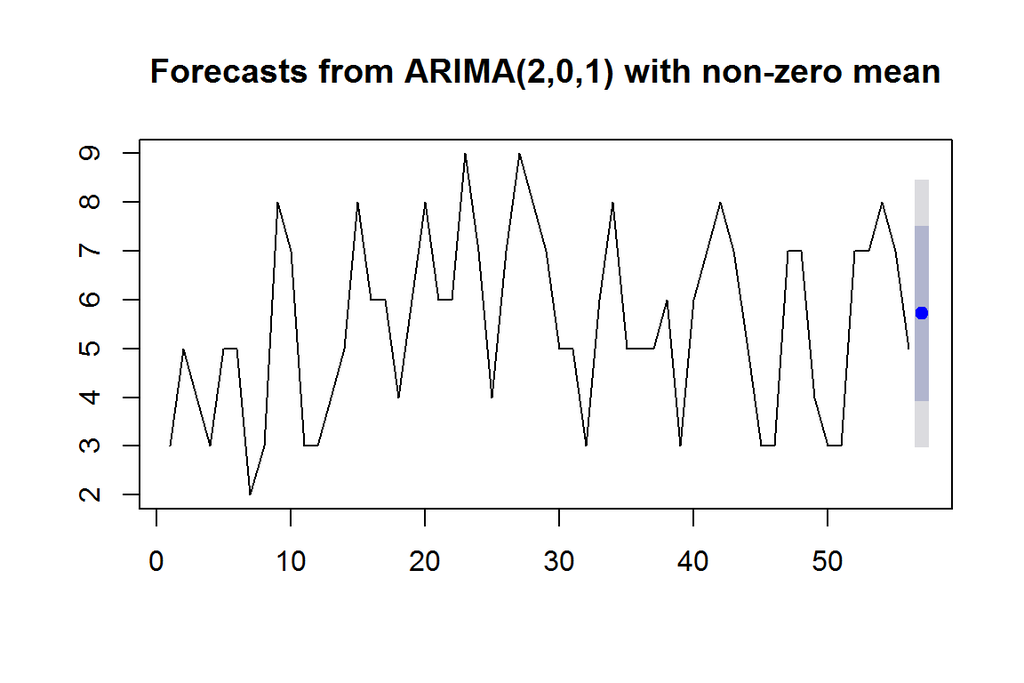

```r
# plot forecast for if do play sports
plot(forecast(object = final.fit, h = 1, xreg = newx1))
```